# SurvBal

## Overview

`SurvBal` enables the selection of microbiome balances in relation to censored survival or time-to-event outcomes, which are of considerable interest in many biomedical studies. The most commonly used survival models – the Cox proportional hazards and parametric survival (including accelerated failure time) models are included in the package, which are used in combination with step-wise selection procedures to identify the optimal associated balance of microbiome, i.e., the ratio of the geometric means of two groups of taxa’s relative abundances.

## Installation

You can install `SurvBal` from GitHub with:

```r
# install.packages("devtools")
devtools::install_github("yinglia/SurvBal")
```

## Getting Started

```r
#loading the library
library(SurvBal)
```

You can load the sample data in `SurvBal` using the following code.

```r
#load example data
data("bacteria")
data("gvhd")
```

`bacteria` is a raw taxon count table with 63 samples and 139 taxa. `gvhd` is a survival object containing time and censoring/event information for each sample.

## Examples

### Select balance based on the Cox proportional hazards model

We can select the balance of microbiome based on the Cox proportional hazards Model by setting `model = "coxph"`.

Here, we specify `mult_repl = TRUE` to use the geometric Bayesian multiplicative replacement method to impute the inflated zeros. If you would like to process the data by adding a small pseudo-count (0.5) to all raw counts instead, set `mult_repl = FALSE`.

We specify `selection_criterion = "min_decrement_pvalue"` so that the decrement of p-value along the forward selection path will be calculated, the balance before the first decrement that is smaller than selection_threshold (the default value is 0.15) will be selected. If “min_pvalue” is used, the balance that has the smallest p-value along the forward selection path will be selected. The default is “min_decrement_pvalue”.

```r
select_coxph = balance_selection(
  Surv_obj = gvhd,
  data = bacteria,
  mult_repl = TRUE,
  model = "coxph",
  selection_criterion = "min_decrement_pvalue"
)
```

We can find the selection path in `selection_path`:

```r
select_coxph$selection_path[,1:2]
```

```
##                                                        taxon_id sign
## Dysosmobacter                                                33    0
## Pseudoflavonifractor capillosus/Clostridium phoceensis       38    1
## Clostridiales Family XIII. Incertae Sedis                    90    0
## Anaerotignum lactatifermentans                               95    1
## Lachnospira eligens                                         127    0
## Eisenbergiella massiliensis                                 124    1
## Massilimicrobiota timonensis                                 81    0
## Acidaminococcus intestini                                    43    1
## Agathobaculum butyriciproducens                             100    0
## [Clostridium] leptum                                         26    0
## Bifidobacterium catenulatum/pseudocatenulatum                55    0
## Parasutterella excrementihominis                             48    1
## Anaerobutyricum soehngenii                                  129    0
## Bacteroides xylanisolvens                                    67    0
## Eubacterium                                                  25    0
## Anaerostipes                                                134    0
## Alistipes putredinis                                         58    0
## Eubacterium ventriosum                                       12    0
## Bilophila wadsworthia                                        45    0
```

We can print the final fitted Cox PH model for the survival outcome, `gvhd` , with the selected balance:

```r
select_coxph$survival_model
```

```
## Call:
## coxph(formula = Surv_obj ~ ., data = df)
##
##           coef exp(coef) se(coef)     z       p
## balance 1.3747    3.9537   0.1806 7.612 2.7e-14
##
## Likelihood ratio test=55.99  on 1 df, p=7.275e-14
## n= 63, number of events= 47
```

```r
summary(select_coxph$survival_model)
```

```
## Call:
## coxph(formula = Surv_obj ~ ., data = df)
##
##   n= 63, number of events= 47
##
##           coef exp(coef) se(coef)     z Pr(>|z|)
## balance 1.3747    3.9537   0.1806 7.612  2.7e-14 ***
## ---
## Signif. codes:  0 '***' 0.001 '**' 0.01 '*' 0.05 '.' 0.1 ' ' 1
##
##         exp(coef) exp(-coef) lower .95 upper .95
## balance     3.954     0.2529     2.775     5.633
##
## Concordance= 0.824  (se = 0.031 )
## Likelihood ratio test= 55.99  on 1 df,   p=7e-14
## Wald test            = 57.94  on 1 df,   p=3e-14
## Score (logrank) test = 68.07  on 1 df,   p=<2e-16
```

We can check which taxa are included in the numerator of the selected balance, as well as taxa in the denominator of the selected balance:

```r
select_coxph$balance_name$numerator
```

```
## [1] "Pseudoflavonifractor capillosus/Clostridium phoceensis"
## [2] "Anaerotignum lactatifermentans"
## [3] "Eisenbergiella massiliensis"
## [4] "Acidaminococcus intestini"
## [5] "Parasutterella excrementihominis"
```

```r
select_coxph$balance_name$denominator
```

```
##  [1] "Dysosmobacter"
##  [2] "Clostridiales Family XIII. Incertae Sedis"
##  [3] "Lachnospira eligens"
##  [4] "Massilimicrobiota timonensis"
##  [5] "Agathobaculum butyriciproducens"
##  [6] "[Clostridium] leptum"
##  [7] "Bifidobacterium catenulatum/pseudocatenulatum"
##  [8] "Anaerobutyricum soehngenii"
##  [9] "Bacteroides xylanisolvens"
## [10] "Eubacterium"
## [11] "Anaerostipes"
## [12] "Alistipes putredinis"
## [13] "Eubacterium ventriosum"
## [14] "Bilophila wadsworthia"
```

And here is the value of the final selected balance of microbiome for each sample:

```r
select_coxph$balance
```

```
##       M-2000       M-2001       M-2002       M-2003       M-2004       M-2005
##  0.837486253 -1.406619798 -1.421036705 -0.204348362 -1.228283054 -0.005997298
##       M-2006       M-2007       M-2008       M-2009       M-2010       M-2013
##  1.779247033 -0.806398850  0.357369533  3.752290061  0.551966669  0.292634946
##       M-2014       M-2018       M-2021       M-2024       M-2030       M-2031
## -1.228931554 -1.239757883  1.684575012 -0.042165288 -0.679476501 -0.564948424
##       M-2035       M-2040       M-2041       M-2043       M-2045       M-2046
##  0.393028222 -0.414389042 -0.884891857  0.352006472  0.044044368  0.850689152
##       M-2049       M-2050       M-2051       M-2054       M-2056       M-2059
##  0.792721982 -0.434479547  0.104701085 -1.269892983 -0.326736863 -0.368146020
##       M-2062       M-2064       M-2066       M-2067       M-2068       M-2069
##  0.715060166 -0.646442335  0.191908746 -1.174924149  1.220369196  0.676698660
##       M-2074       M-2077       M-2079       M-2082       M-2084       M-2085
## -0.248523821 -0.221243932 -0.732856713 -0.402435682 -0.362810395  0.165101075
##       M-2087       M-2090       M-2091       M-2092       M-2094       M-2095
## -0.073229491  0.044846394  1.492174624 -1.665548697 -1.025799358 -0.179534268
##       M-2096       M-2098       M-2099       M-2101       M-2108       M-2109
## -0.818456580  2.142694112 -0.430141030  1.974103121 -0.609331350  0.921126209
##       M-2111       M-2115       M-2122       M-2123       M-2124       M-2125
##  0.600699874  0.183049924 -0.749427856  0.550366098 -0.667610499 -1.546930652
##       M-2128       M-2168       M-2169
##  0.587784622 -0.647886850 -0.233900172
```

Finally, we can visualize the survival plot with respect to several quantiles of the final selected balance of microbiome with `1-alpha` confidence interval. The quantiles of the final selected balance for plot are specified through the argument `quantile_plotted`, of which the default value is `c(0.25, 0.75)`. The default value of alpha is `0.05`.

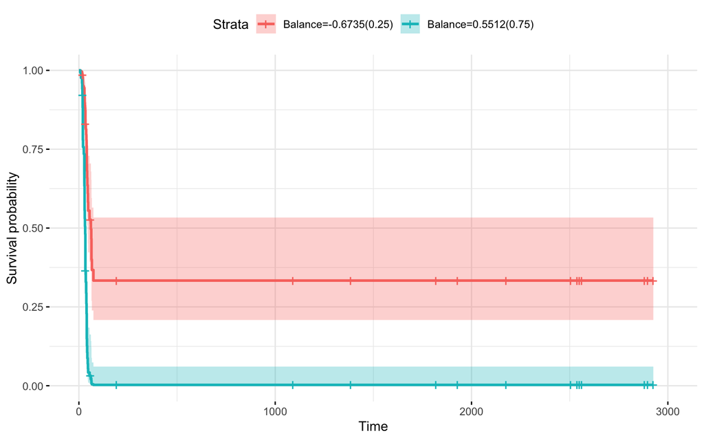

```r
select_coxph$survival_plot
```

From the plot, we can see that the 25th percentile (lower quartile) of the sample microbiome balance is -0.6735, and the 75th percentile (upper quartile) is 0.5512. The survival curves for the two corresponding values of the microbiome balance are shown in the plot.

### Select balance based on the parametric survival model

We can also select the balance based on the parametric survival model by setting `model = "parametric"` , and specify the distribution via the argument `dist`.

```r
select_weibull = balance_selection(
  Surv_obj = gvhd,
  data = bacteria,
  mult_repl = FALSE,
  model = "parametric",
  dist = "weibull",
  selection_criterion = "min_decrement_pvalue"
)
```

Similarly, we can find the selection path in `selection_path`:

```r
select_weibull$selection_path[,1:2]
```

```
##                                           taxon_id sign
## [Ruminococcus] faecis                            8    1
## Dorea                                          102    0
## Clostridiales Family XIII. Incertae Sedis       90    1
## Anaerotignum lactatifermentans                  95    0
## Coprococcus                                     14    1
## Acidaminococcus intestini                       43    0
## Neglecta                                        29    0
## Anaerobutyricum soehngenii                     129    1
## Intestinimonas v2                               36    0
## Massilimicrobiota timonensis                    81    1
## Longicatena caecimuris                          75    0
## Anaerobutyricum hallii                         131    0
## Coprococcus comes                              112    1
## Dysosmobacter                                   33    1
## Agathobaculum butyriciproducens                100    1
```

We can print the final fitted parametric survival model for the survival outcome, `gvhd`, with the selected balance:

```r
select_weibull$survival_model
```

```
## Call:
## survreg(formula = Surv_obj ~ ., data = df, dist = dist)
##
## Coefficients:
## (Intercept)     balance
##    5.769075    1.650078
##
## Scale= 1.199659
##
## Loglik(model)= -258.6   Loglik(intercept only)= -295.3
##  Chisq= 73.41 on 1 degrees of freedom, p= <2e-16
## n= 63
```

We can check which taxa are included in the numerator of the selected balance, as well as taxa in the denominator of the selected balance:

```r
select_weibull$balance_name
```

```
## $numerator
## [1] "[Ruminococcus] faecis"
## [2] "Clostridiales Family XIII. Incertae Sedis"
## [3] "Coprococcus"
## [4] "Anaerobutyricum soehngenii"
## [5] "Massilimicrobiota timonensis"
## [6] "Coprococcus comes"
## [7] "Dysosmobacter"
## [8] "Agathobaculum butyriciproducens"
##
## $denominator
## [1] "Dorea"                          "Anaerotignum lactatifermentans"
## [3] "Acidaminococcus intestini"      "Neglecta"
## [5] "Intestinimonas v2"              "Longicatena caecimuris"
## [7] "Anaerobutyricum hallii"
```

And here is the value of the final selected balance of microbiome for each sample:

```r
select_weibull$balance
```

```
##      M-2000      M-2001      M-2002      M-2003      M-2004      M-2005
##  0.00000000  2.04057566 -0.01319373 -0.75699431  0.93550620  1.35663561
##      M-2006      M-2007      M-2008      M-2009      M-2010      M-2013
## -0.47998351  0.65783627 -1.05440428 -3.55409033 -1.73662766 -0.70293243
##      M-2014      M-2018      M-2021      M-2024      M-2030      M-2031
##  1.15979605  1.34995970 -0.86751417 -1.16936496  2.08546971 -0.62975327
##      M-2035      M-2040      M-2041      M-2043      M-2045      M-2046
## -0.72669106 -1.60148802  1.16110388  0.25503500 -1.32013808 -0.93820266
##      M-2049      M-2050      M-2051      M-2054      M-2056      M-2059
## -0.14414414 -0.17656269 -1.26209604  1.16819286 -1.25011071  0.41197961
##      M-2062      M-2064      M-2066      M-2067      M-2068      M-2069
## -1.38818211 -0.04957122 -1.20049269 -0.59210268 -1.56215146 -1.02600843
##      M-2074      M-2077      M-2079      M-2082      M-2084      M-2085
## -0.31388923  0.27465307  1.09060275 -1.27005905  0.11770846 -0.61724786
##      M-2087      M-2090      M-2091      M-2092      M-2094      M-2095
## -0.06916086 -1.72846110 -1.79710092  1.03588867  1.24154467 -0.43826587
##      M-2096      M-2098      M-2099      M-2101      M-2108      M-2109
## -0.22965446 -0.95661076 -0.17400633 -1.52564103 -0.40173157 -0.95808157
##      M-2111      M-2115      M-2122      M-2123      M-2124      M-2125
## -1.87655712  0.05168391  0.11770846 -1.57673097  0.07865761  1.31621642
##      M-2128      M-2168      M-2169
## -0.80668017 -1.71446159  0.27465307
```

Finally, we can visualize the survival plot:

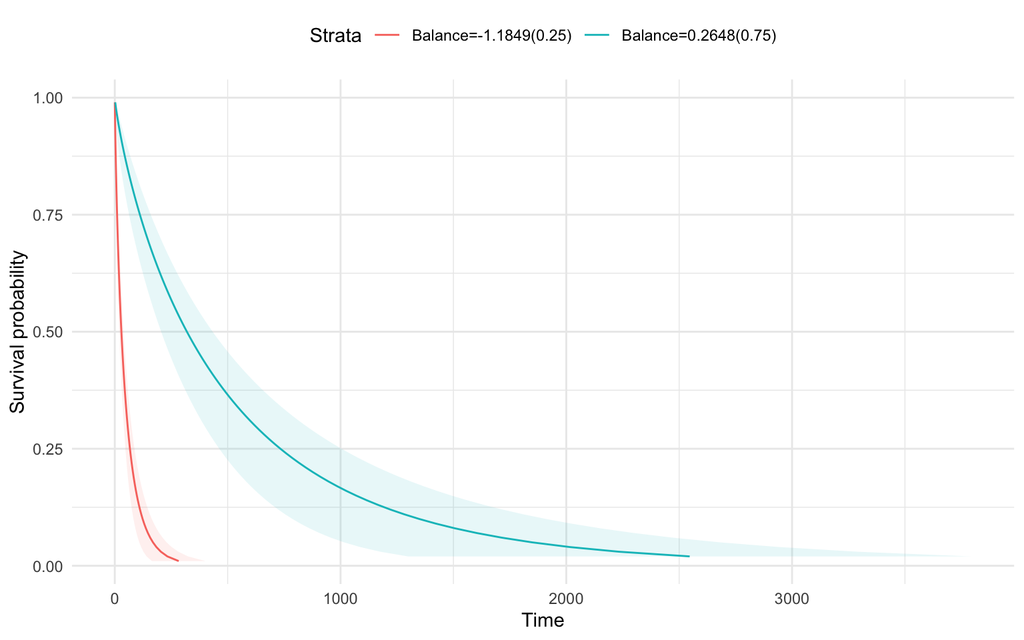

```r
select_weibull$survival_plot
```